# Prediction of the antenna of good pass through the space.

`ASAD ASHRAF KAREL`

#### RADAR stands for Radio Detection and Ranging System. It is basically an electromagnetic system used to detect the location and distance of an object from the point where the RADAR is placed. It works by radiating energy into space and monitoring the echo or reflected signal from the objects.

### About the data:

`This radar data was collected by a system in Goose Bay, Labrador. This system consists of a phased array of 16 high-frequency antennas with a total transmitted power on the order of 6.4 kilowatts. See the paper for more details. The targets were free electrons in the ionosphere. "good" radar returns are those showing evidence of some type of structure in the ionosphere. "bad" returns are those that do not; their signals pass through the ionosphere.`

`Received signals were processed using an autocorrelation function whose arguments are the time of a pulse and the pulse number. There were 17 pulse numbers for the Goose Bay system. Instances in this databse are described by 2 attributes per pulse number, corresponding to the complex values returned by the function resulting from the complex electromagnetic signal. See cited below for more details.`

### Usage

data(Ionosphere)

### Source

Source: Space Physics Group; Applied Physics Laboratory; Johns Hopkins University; Johns Hopkins Road; Laurel; MD 20723 Donor: Vince Sigillito (vgs@aplcen.apl.jhu.edu)

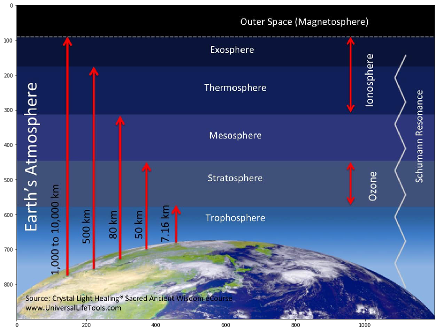

```python
import matplotlib.pyplot as plt
plt.figure(figsize = (15,15))
image = plt.imread('Schumann-Resonance-Ionosphere.jpg')
plt.imshow(image)
plt.show()
```

Author: Space Physics Group, Applied Physics Laboratory, Johns Hopkins University. Donated by Vince Sigillito. Source: [UCI Machine Learning Repository](https://archive.ics.uci.edu/ml/datasets/ionosphere) -1989-01-01 Please cite: [UCI](https://archive.ics.uci.edu/ml/citation_policy.html)

Johns Hopkins University Ionosphere database This radar data was collected by a system in Goose Bay, Labrador. This system consists of a phased array of 16 high-frequency antennas with a total transmitted power on the order of 6.4 kilowatts. See the paper for more details.

### Attribute information

Received signals were processed using an autocorrelation function whose arguments are the time of a pulse and the pulse number. There were 17 pulse numbers for the Goose Bay system. Instances in this database are described by 2 attributes per pulse number, corresponding to the complex values returned by the function resulting from the complex electromagnetic signal.

The targets were free electrons in the ionosphere. "Good" (g) radar returns are those showing evidence of some type of structure in the ionosphere. "Bad" (b) returns are those that do not; their signals pass through the ionosphere.

### Relevant papers

Sigillito, V. G., Wing, S. P., Hutton, L. V., & Baker, K. B. (1989). Classification of radar returns from the ionosphere using neural networks. Johns Hopkins APL Technical Digest, 10, 262-266.

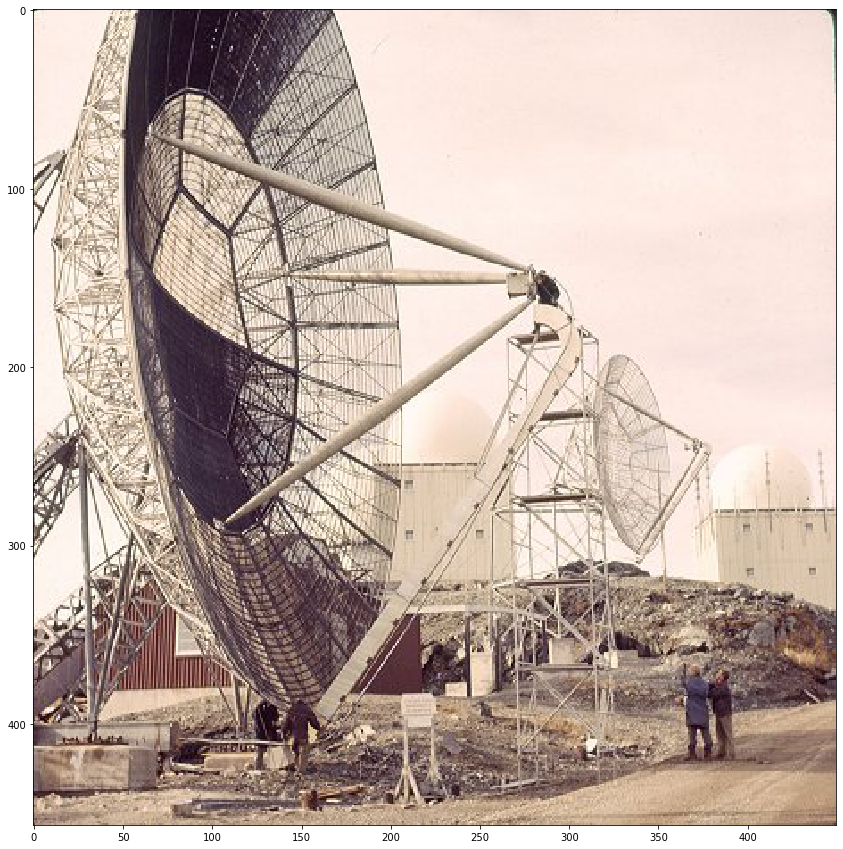

```python
import matplotlib.pyplot as plt
plt.figure(figsize = (15,15))
image = plt.imread('Re00e0edb854c9bc549137e556e2c17c4.jpg')
plt.imshow(image)
plt.show()
```

```
A simple Analysis picture.
```

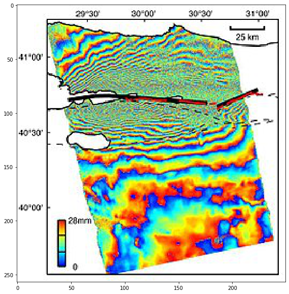

```python
print('A simple Analysis picture.')
import matplotlib.pyplot as plt
plt.figure(figsize = (10,10))
image = plt.imread('250px-Izmit_interferogram.jpg')
plt.imshow(image)
plt.show()
```

```python
import pandas as pd

plt.rcParams['figure.figsize'] = [15,8]
```

```python
ionosphere = pd.read_csv('dataset_59_ionosphere.csv')
```

```python
ionosphere.head()
```

|  | a01 | a02 | a03 | a04 | a05 | a06 | a07 | a08 | a09 | a10 | ... | a26 | a27 | a28 | a29 | a30 | a31 | a32 | a33 | a34 | class |
| --- | --- | --- | --- | --- | --- | --- | --- | --- | --- | --- | --- | --- | --- | --- | --- | --- | --- | --- | --- | --- | --- |
| 0 | 1 | 0 | 0.99539 | -0.05889 | 0.85243 | 0.02306 | 0.83398 | -0.37708 | 1.00000 | 0.03760 | ... | -0.51171 | 0.41078 | -0.46168 | 0.21266 | -0.34090 | 0.42267 | -0.54487 | 0.18641 | -0.45300 | g |
| 1 | 1 | 0 | 1.00000 | -0.18829 | 0.93035 | -0.36156 | -0.10868 | -0.93597 | 1.00000 | -0.04549 | ... | -0.26569 | -0.20468 | -0.18401 | -0.19040 | -0.11593 | -0.16626 | -0.06288 | -0.13738 | -0.02447 | b |
| 2 | 1 | 0 | 1.00000 | -0.03365 | 1.00000 | 0.00485 | 1.00000 | -0.12062 | 0.88965 | 0.01198 | ... | -0.40220 | 0.58984 | -0.22145 | 0.43100 | -0.17365 | 0.60436 | -0.24180 | 0.56045 | -0.38238 | g |
| 3 | 1 | 0 | 1.00000 | -0.45161 | 1.00000 | 1.00000 | 0.71216 | -1.00000 | 0.00000 | 0.00000 | ... | 0.90695 | 0.51613 | 1.00000 | 1.00000 | -0.20099 | 0.25682 | 1.00000 | -0.32382 | 1.00000 | b |
| 4 | 1 | 0 | 1.00000 | -0.02401 | 0.94140 | 0.06531 | 0.92106 | -0.23255 | 0.77152 | -0.16399 | ... | -0.65158 | 0.13290 | -0.53206 | 0.02431 | -0.62197 | -0.05707 | -0.59573 | -0.04608 | -0.65697 | g |

5 rows × 35 columns

```python
ionosphere.isna().sum()
```

```
a01      0
a02      0
a03      0
a04      0
a05      0
a06      0
a07      0
a08      0
a09      0
a10      0
a11      0
a12      0
a13      0
a14      0
a15      0
a16      0
a17      0
a18      0
a19      0
a20      0
a21      0
a22      0
a23      0
a24      0
a25      0
a26      0
a27      0
a28      0
a29      0
a30      0
a31      0
a32      0
a33      0
a34      0
class    0
dtype: int64
```

```python
(ionosphere['class'].value_counts()/ionosphere.shape[0])*100
```

```
g    64.102564
b    35.897436
Name: class, dtype: float64
```

Data seems little imbalanced.

## Visualization:

```python
t_class = ionosphere['class'].value_counts()
```

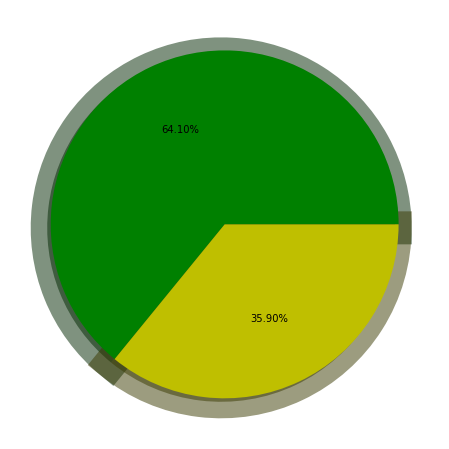

```python
plt.figure(figsize = (8,8))
plt.pie(t_class, colors=['g','y'], autopct='%1.2f%%', shadow = True, wedgeprops = {'linewidth': 33})
plt.show()
```

### We see the data, which is good for prediction of good antenna or bad antenna. Data is distributed in the form of 64:36 of the ratio. A little imbalancing of the data.

**We are about to work on other insights of the data.**

```python
ionosphere.shape
```

```
(351, 35)
```

```python
from warnings import filterwarnings
filterwarnings('ignore')
```

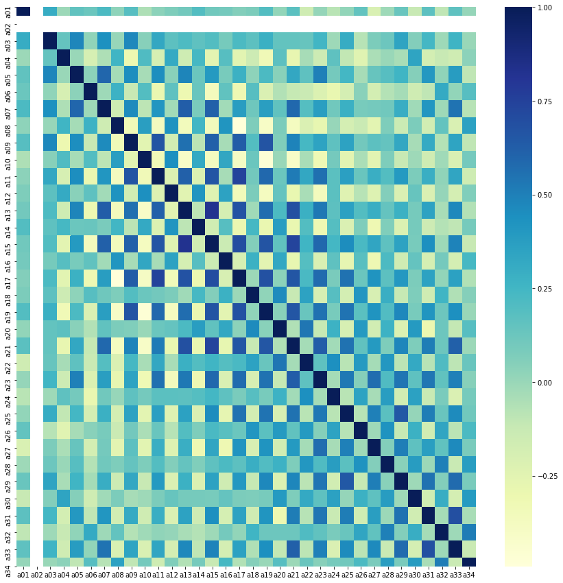

```python
import seaborn as sns
plt.figure(figsize = (15,15))
sns.heatmap(ionosphere.corr(), cmap="YlGnBu")
plt.show()
```

```python
describe = ionosphere.describe()
```

```python
print(describe.T)
```

```
     count      mean       std  min       25%      50%       75%  max
a01  351.0  0.891738  0.311155  0.0  1.000000  1.00000  1.000000  1.0
a02  351.0  0.000000  0.000000  0.0  0.000000  0.00000  0.000000  0.0
a03  351.0  0.641342  0.497708 -1.0  0.472135  0.87111  1.000000  1.0
a04  351.0  0.044372  0.441435 -1.0 -0.064735  0.01631  0.194185  1.0
a05  351.0  0.601068  0.519862 -1.0  0.412660  0.80920  1.000000  1.0
a06  351.0  0.115889  0.460810 -1.0 -0.024795  0.02280  0.334655  1.0
a07  351.0  0.550095  0.492654 -1.0  0.211310  0.72873  0.969240  1.0
a08  351.0  0.119360  0.520750 -1.0 -0.054840  0.01471  0.445675  1.0
a09  351.0  0.511848  0.507066 -1.0  0.087110  0.68421  0.953240  1.0
a10  351.0  0.181345  0.483851 -1.0 -0.048075  0.01829  0.534195  1.0
a11  351.0  0.476183  0.563496 -1.0  0.021120  0.66798  0.957895  1.0
a12  351.0  0.155040  0.494817 -1.0 -0.065265  0.02825  0.482375  1.0
a13  351.0  0.400801  0.622186 -1.0  0.000000  0.64407  0.955505  1.0
a14  351.0  0.093414  0.494873 -1.0 -0.073725  0.03027  0.374860  1.0
a15  351.0  0.344159  0.652828 -1.0  0.000000  0.60194  0.919330  1.0
a16  351.0  0.071132  0.458371 -1.0 -0.081705  0.00000  0.308975  1.0
a17  351.0  0.381949  0.618020 -1.0  0.000000  0.59091  0.935705  1.0
a18  351.0 -0.003617  0.496762 -1.0 -0.225690  0.00000  0.195285  1.0
a19  351.0  0.359390  0.626267 -1.0  0.000000  0.57619  0.899265  1.0
a20  351.0 -0.024025  0.519076 -1.0 -0.234670  0.00000  0.134370  1.0
a21  351.0  0.336695  0.609828 -1.0  0.000000  0.49909  0.894865  1.0
a22  351.0  0.008296  0.518166 -1.0 -0.243870  0.00000  0.188760  1.0
a23  351.0  0.362475  0.603767 -1.0  0.000000  0.53176  0.911235  1.0
a24  351.0 -0.057406  0.527456 -1.0 -0.366885  0.00000  0.164630  1.0
a25  351.0  0.396135  0.578451 -1.0  0.000000  0.55389  0.905240  1.0
a26  351.0 -0.071187  0.508495 -1.0 -0.332390 -0.01505  0.156765  1.0
a27  351.0  0.541641  0.516205 -1.0  0.286435  0.70824  0.999945  1.0
a28  351.0 -0.069538  0.550025 -1.0 -0.443165 -0.01769  0.153535  1.0
a29  351.0  0.378445  0.575886 -1.0  0.000000  0.49664  0.883465  1.0
a30  351.0 -0.027907  0.507974 -1.0 -0.236885  0.00000  0.154075  1.0
a31  351.0  0.352514  0.571483 -1.0  0.000000  0.44277  0.857620  1.0
a32  351.0 -0.003794  0.513574 -1.0 -0.242595  0.00000  0.200120  1.0
a33  351.0  0.349364  0.522663 -1.0  0.000000  0.40956  0.813765  1.0
a34  351.0  0.014480  0.468337 -1.0 -0.165350  0.00000  0.171660  1.0
```

`From above two observation of heatmap and describe with std of the attributes, we observe that, the feature a02 does not contribute into the data. hence this will be unused for Machine Learning prediction. We are going to drop this feature permanently to reduce the dimensionality.`

```python
ionosphere = ionosphere.drop('a02', axis = 1)
```

### Finally we have our data ionosphere.

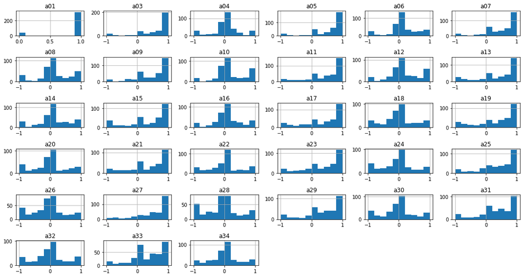

```python
ionosphere.hist()

plt.tight_layout()
plt.show()
```

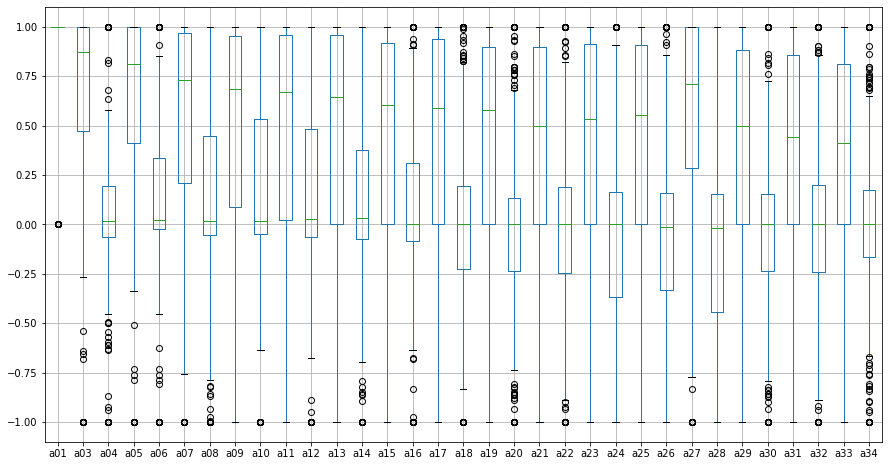

```python
ionosphere.boxplot()
plt.show()
```

**Many features consist of outliers, but still we are free not to remove the outliers, since we know about some algorithms like Random Forest algorithm or Ensemble technique which basically works on the vote base, are not affected by outliers.**

```python
ionosphere.skew()
```

```
a01   -2.532392
a03   -1.851541
a04   -0.228268
a05   -1.627778
a06   -0.279440
a07   -1.307027
a08   -0.217991
a09   -1.091865
a10   -0.028738
a11   -1.044918
a12   -0.081149
a13   -0.876225
a14   -0.219482
a15   -0.775888
a16   -0.098106
a17   -0.821593
a18    0.005083
a19   -0.833409
a20    0.059601
a21   -0.665995
a22    0.066805
a23   -0.744519
a24    0.045253
a25   -0.881588
a26    0.053157
a27   -1.287053
a28    0.066707
a29   -0.885749
a30    0.031059
a31   -0.810506
a32    0.069350
a33   -0.606070
a34    0.112646
dtype: float64
```

Some of them are left skewed.

# Machine Learning Classification algorithms to predict the quality of radar by recieved signals.

```python
ionosphere.head()
```

|  | a01 | a03 | a04 | a05 | a06 | a07 | a08 | a09 | a10 | a11 | ... | a26 | a27 | a28 | a29 | a30 | a31 | a32 | a33 | a34 | class |
| --- | --- | --- | --- | --- | --- | --- | --- | --- | --- | --- | --- | --- | --- | --- | --- | --- | --- | --- | --- | --- | --- |
| 0 | 1 | 0.99539 | -0.05889 | 0.85243 | 0.02306 | 0.83398 | -0.37708 | 1.00000 | 0.03760 | 0.85243 | ... | -0.51171 | 0.41078 | -0.46168 | 0.21266 | -0.34090 | 0.42267 | -0.54487 | 0.18641 | -0.45300 | g |
| 1 | 1 | 1.00000 | -0.18829 | 0.93035 | -0.36156 | -0.10868 | -0.93597 | 1.00000 | -0.04549 | 0.50874 | ... | -0.26569 | -0.20468 | -0.18401 | -0.19040 | -0.11593 | -0.16626 | -0.06288 | -0.13738 | -0.02447 | b |
| 2 | 1 | 1.00000 | -0.03365 | 1.00000 | 0.00485 | 1.00000 | -0.12062 | 0.88965 | 0.01198 | 0.73082 | ... | -0.40220 | 0.58984 | -0.22145 | 0.43100 | -0.17365 | 0.60436 | -0.24180 | 0.56045 | -0.38238 | g |
| 3 | 1 | 1.00000 | -0.45161 | 1.00000 | 1.00000 | 0.71216 | -1.00000 | 0.00000 | 0.00000 | 0.00000 | ... | 0.90695 | 0.51613 | 1.00000 | 1.00000 | -0.20099 | 0.25682 | 1.00000 | -0.32382 | 1.00000 | b |
| 4 | 1 | 1.00000 | -0.02401 | 0.94140 | 0.06531 | 0.92106 | -0.23255 | 0.77152 | -0.16399 | 0.52798 | ... | -0.65158 | 0.13290 | -0.53206 | 0.02431 | -0.62197 | -0.05707 | -0.59573 | -0.04608 | -0.65697 | g |

5 rows × 34 columns

```python
ionosphere['class'] = ionosphere['class'].replace(to_replace = ['g', 'b'], value = [1,0])
```

```python
ionosphere.head()
```

|  | a01 | a03 | a04 | a05 | a06 | a07 | a08 | a09 | a10 | a11 | ... | a26 | a27 | a28 | a29 | a30 | a31 | a32 | a33 | a34 | class |
| --- | --- | --- | --- | --- | --- | --- | --- | --- | --- | --- | --- | --- | --- | --- | --- | --- | --- | --- | --- | --- | --- |
| 0 | 1 | 0.99539 | -0.05889 | 0.85243 | 0.02306 | 0.83398 | -0.37708 | 1.00000 | 0.03760 | 0.85243 | ... | -0.51171 | 0.41078 | -0.46168 | 0.21266 | -0.34090 | 0.42267 | -0.54487 | 0.18641 | -0.45300 | 1 |
| 1 | 1 | 1.00000 | -0.18829 | 0.93035 | -0.36156 | -0.10868 | -0.93597 | 1.00000 | -0.04549 | 0.50874 | ... | -0.26569 | -0.20468 | -0.18401 | -0.19040 | -0.11593 | -0.16626 | -0.06288 | -0.13738 | -0.02447 | 0 |
| 2 | 1 | 1.00000 | -0.03365 | 1.00000 | 0.00485 | 1.00000 | -0.12062 | 0.88965 | 0.01198 | 0.73082 | ... | -0.40220 | 0.58984 | -0.22145 | 0.43100 | -0.17365 | 0.60436 | -0.24180 | 0.56045 | -0.38238 | 1 |
| 3 | 1 | 1.00000 | -0.45161 | 1.00000 | 1.00000 | 0.71216 | -1.00000 | 0.00000 | 0.00000 | 0.00000 | ... | 0.90695 | 0.51613 | 1.00000 | 1.00000 | -0.20099 | 0.25682 | 1.00000 | -0.32382 | 1.00000 | 0 |
| 4 | 1 | 1.00000 | -0.02401 | 0.94140 | 0.06531 | 0.92106 | -0.23255 | 0.77152 | -0.16399 | 0.52798 | ... | -0.65158 | 0.13290 | -0.53206 | 0.02431 | -0.62197 | -0.05707 | -0.59573 | -0.04608 | -0.65697 | 1 |

5 rows × 34 columns

### Our data is prepared for Machine Learning algorithms.

Data features and vector prediction separation:

```python
X = ionosphere.drop('class', axis =1)
y = ionosphere['class']
```

Train test split of the data

```python
from sklearn.model_selection import train_test_split as splt
```

```python
Xtrain, Xtest, ytrain, ytest = splt(X,y, test_size=0.4)
```

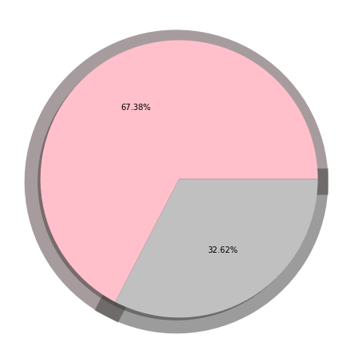

```python
plt.figure(figsize = (8,8))
plt.pie(ytest.value_counts(), colors=['pink','silver'], autopct='%1.2f%%', shadow = True, wedgeprops = {'linewidth': 33})
plt.show()
```

# 1) Logistic Regression:

```python
from sklearn.linear_model import LogisticRegression
```

```python
LR = LogisticRegression(solver = 'saga', max_iter = 200)

LR.fit(Xtrain, ytrain)

print('Accuracy for the train dataset:',LR.score(Xtrain, ytrain))
print('Accuracy for the test dataset:',LR.score(Xtest, ytest).round(3))
```

```
Accuracy for the train dataset: 0.9428571428571428
Accuracy for the test dataset: 0.851
```

### Insight:

```python
log_pred = LR.fit(Xtrain, ytrain).predict(Xtest)
```

```python
Xlog = Xtest.copy()
Xlog.head()
```

|  | a01 | a03 | a04 | a05 | a06 | a07 | a08 | a09 | a10 | a11 | ... | a25 | a26 | a27 | a28 | a29 | a30 | a31 | a32 | a33 | a34 |
| --- | --- | --- | --- | --- | --- | --- | --- | --- | --- | --- | --- | --- | --- | --- | --- | --- | --- | --- | --- | --- | --- |
| 299 | 1 | 0.83479 | 0.28993 | 0.69256 | 0.47702 | 0.49234 | 0.68381 | 0.21991 | 0.86761 | -0.08096 | ... | -0.37199 | -0.52954 | -0.16950 | -0.60863 | 0.08425 | -0.61488 | 0.25164 | -0.48468 | 0.40591 | -0.35339 |
| 175 | 1 | 1.00000 | 0.11765 | 1.00000 | 0.23529 | 1.00000 | 0.41176 | 1.00000 | 0.05882 | 1.00000 | ... | 1.00000 | -0.11765 | 1.00000 | 0.20225 | 1.00000 | 0.05882 | 1.00000 | 0.35294 | 1.00000 | 0.23529 |
| 106 | 1 | 0.00000 | 0.00000 | 0.00000 | 0.00000 | 0.00000 | 0.00000 | 0.00000 | 0.00000 | 0.62195 | ... | 0.00000 | 0.00000 | 1.00000 | 0.10976 | 0.00000 | 0.00000 | 0.00000 | 0.00000 | 0.00000 | 0.00000 |
| 306 | 1 | 0.33333 | -0.25000 | 0.44444 | 0.22222 | 0.38889 | 0.16667 | 0.41667 | 0.13889 | 0.50000 | ... | 0.38889 | 0.08333 | 0.41543 | -0.14256 | 0.19444 | -0.13889 | 0.36924 | -0.14809 | 0.08333 | -0.50000 |
| 342 | 1 | 0.82254 | -0.07572 | 0.80462 | 0.00231 | 0.87514 | -0.01214 | 0.86821 | -0.07514 | 0.72832 | ... | 0.74451 | -0.02370 | 0.76717 | -0.02731 | 0.74046 | -0.07630 | 0.70058 | -0.04220 | 0.78439 | 0.01214 |

5 rows × 33 columns

```python
Xlog['class'] = log_pred
```

## Predictions:

```python
df1 = Xlog.iloc[:5,-3:].head()
df1
```

|  | a33 | a34 | class |
| --- | --- | --- | --- |
| 299 | 0.40591 | -0.35339 | 1 |
| 175 | 1.00000 | 0.23529 | 1 |
| 106 | 0.00000 | 0.00000 | 0 |
| 306 | 0.08333 | -0.50000 | 1 |
| 342 | 0.78439 | 0.01214 | 1 |

```python
ionosphere.iloc[df1.index, -3:]
```

|  | a33 | a34 | class |
| --- | --- | --- | --- |
| 299 | 0.40591 | -0.35339 | 1 |
| 175 | 1.00000 | 0.23529 | 1 |
| 106 | 0.00000 | 0.00000 | 0 |
| 306 | 0.08333 | -0.50000 | 1 |
| 342 | 0.78439 | 0.01214 | 1 |

This is just for 5 observations. It goes 90% for the entire dataset.

```python
df1['class'] = df1['class'].replace(to_replace = [1,0], value = ['Good', 'Bad'])
```

```python
df1
```

|  | a33 | a34 | class |
| --- | --- | --- | --- |
| 299 | 0.40591 | -0.35339 | Good |
| 175 | 1.00000 | 0.23529 | Good |
| 106 | 0.00000 | 0.00000 | Bad |
| 306 | 0.08333 | -0.50000 | Good |
| 342 | 0.78439 | 0.01214 | Good |

```python
Xlog['class'] = Xlog['class'].replace(to_replace = [1,0], value = ['Good', 'Bad'])
print('These are the good radars which cross the ionosphere.')
print(list(Xlog[Xlog['class'] == 'Good'].index))
print()
print('These are the bad radars which cross the ionosphere.')
print(list(Xlog[Xlog['class'] == 'Bad'].index))
```

```
These are the good radars which cross the ionosphere.
[299, 175, 306, 342, 251, 331, 277, 278, 191, 98, 129, 116, 193, 257, 322, 85, 25, 14, 323, 265, 321, 81, 245, 92, 1, 307, 256, 327, 334, 205, 298, 151, 30, 228, 167, 333, 219, 145, 336, 65, 189, 101, 260, 72, 161, 347, 203, 87, 264, 223, 237, 337, 13, 114, 39, 338, 291, 28, 38, 2, 56, 195, 174, 149…

These are the bad radars which cross the ionosphere.
[106, 23, 156, 27, 61, 152, 35, 102, 154, 124, 19, 158, 57, 136, 168, 45, 9, 222, 146, 21, 250, 143, 214, 53, 252, 93, 178]
```

```python
import statsmodels.api as sm
```

```python
logit = sm.Logit( ytrain, Xtrain).fit()
```

```
Optimization terminated successfully.
         Current function value: 0.143088
         Iterations 10
```

```python
print(logit.summary())
```

```
                           Logit Regression Results
==============================================================================
Dep. Variable:                  class   No. Observations:                  210
Model:                          Logit   Df Residuals:                      177
Method:                           MLE   Df Model:                           32
Date:                Mon, 15 Mar 2021   Pseudo R-squ.:                  0.7847
Time:                        17:34:19   Log-Likelihood:                -30.049
converged:                       True   LL-Null:                       -139.55
Covariance Type:            nonrobust   LLR p-value:                 9.590e-30
==============================================================================
                 coef    std err          z      P>|z|      [0.025      0.975]
------------------------------------------------------------------------------
a01           -2.1148      0.946     -2.235      0.025      -3.969      -0.260
a03            5.1123      2.030      2.519      0.012       1.134       9.090
a04           -0.2863      1.760     -0.163      0.871      -3.736       3.164
a05            5.8837      2.312      2.545      0.011       1.353      10.414
a06            2.6726      1.663      1.607      0.108      -0.586       5.931
a07           -3.6212      2.034     -1.781      0.075      -7.607       0.365
a08            4.8293      1.760      2.743      0.006       1.379       8.280
a09            3.6985      2.449      1.510      0.131      -1.101       8.498
a10           -0.6032      1.281     -0.471      0.638      -3.113       1.907
a11           -5.9451      2.086     -2.850      0.004     -10.034      -1.856
a12           -2.1300      1.788     -1.192      0.233      -5.634       1.374
a13           -2.0002      1.760     -1.136      0.256      -5.450       1.450
a14            3.1439      1.297      2.423      0.015       0.601       5.687
a15            4.1331      1.880      2.199      0.028       0.449       7.817
a16           -1.1223      1.617     -0.694      0.488      -4.291       2.046
a17            4.2570      1.936      2.199      0.028       0.463       8.051
a18            0.4779      1.857      0.257      0.797      -3.161       4.117
a19           -2.3827      2.119     -1.124      0.261      -6.536       1.771
a20           -1.7537      1.957     -0.896      0.370      -5.590       2.083
a21            0.3533      2.483      0.142      0.887      -4.514       5.221
a22           -5.1337      1.597     -3.215      0.001      -8.264      -2.004
a23            1.6286      2.072      0.786      0.432      -2.432       5.689
a24            2.8533      1.533      1.862      0.063      -0.151       5.857
a25           -1.4130      1.271     -1.112      0.266      -3.904       1.078
a26            0.5960      1.508      0.395      0.693      -2.360       3.552
a27           -8.9861      2.111     -4.257      0.000     -13.123      -4.849
a28            0.7556      1.657      0.456      0.648      -2.492       4.004
a29            2.3620      1.368      1.727      0.084      -0.319       5.043
a30            1.9423      1.469      1.322      0.186      -0.937       4.822
a31            1.2349      1.752      0.705      0.481      -2.199       4.669
a32           -1.4422      1.588     -0.908      0.364      -4.554       1.670
a33            2.7958      2.240      1.248      0.212      -1.595       7.187
a34           -2.4523      1.912     -1.282      0.200      -6.201       1.296
==============================================================================

Possibly complete quasi-separation: A fraction 0.16 of observations can be
perfectly predicted. This might indicate that there is complete
quasi-separation. In this case some parameters will not be identified.
```

## Confusion Matrix

```python
import scikitplot as skplt
```

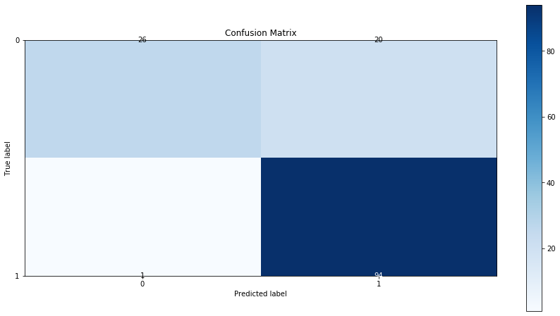

```python
skplt.metrics.plot_confusion_matrix(ytest, log_pred)
plt.show()
```

Let's deduce Precesion, Recall and f1 score with their respective plot. Also prediction on cross validation.

```python
from sklearn.model_selection import cross_val_score, cross_val_predict
```

```python
log_cross_val_score = cross_val_score(LR, Xtrain, ytrain, cv = 3)
log_cross_pred = cross_val_predict(LR, Xtest, ytest, cv = 3)
```

```python
print(log_cross_val_score)
```

```
[0.85915493 0.88571429 0.85507246]
```

Respective Scores of each fold

```python
LR.score(Xtest, log_cross_pred)
```

```
0.9148936170212766
```

Let's gain make another prediction table with this accuracy into the data.

```python
Xlog_cross = Xtest.copy()
Xlog_cross.head()
```

|  | a01 | a03 | a04 | a05 | a06 | a07 | a08 | a09 | a10 | a11 | ... | a25 | a26 | a27 | a28 | a29 | a30 | a31 | a32 | a33 | a34 |
| --- | --- | --- | --- | --- | --- | --- | --- | --- | --- | --- | --- | --- | --- | --- | --- | --- | --- | --- | --- | --- | --- |
| 299 | 1 | 0.83479 | 0.28993 | 0.69256 | 0.47702 | 0.49234 | 0.68381 | 0.21991 | 0.86761 | -0.08096 | ... | -0.37199 | -0.52954 | -0.16950 | -0.60863 | 0.08425 | -0.61488 | 0.25164 | -0.48468 | 0.40591 | -0.35339 |
| 175 | 1 | 1.00000 | 0.11765 | 1.00000 | 0.23529 | 1.00000 | 0.41176 | 1.00000 | 0.05882 | 1.00000 | ... | 1.00000 | -0.11765 | 1.00000 | 0.20225 | 1.00000 | 0.05882 | 1.00000 | 0.35294 | 1.00000 | 0.23529 |
| 106 | 1 | 0.00000 | 0.00000 | 0.00000 | 0.00000 | 0.00000 | 0.00000 | 0.00000 | 0.00000 | 0.62195 | ... | 0.00000 | 0.00000 | 1.00000 | 0.10976 | 0.00000 | 0.00000 | 0.00000 | 0.00000 | 0.00000 | 0.00000 |
| 306 | 1 | 0.33333 | -0.25000 | 0.44444 | 0.22222 | 0.38889 | 0.16667 | 0.41667 | 0.13889 | 0.50000 | ... | 0.38889 | 0.08333 | 0.41543 | -0.14256 | 0.19444 | -0.13889 | 0.36924 | -0.14809 | 0.08333 | -0.50000 |
| 342 | 1 | 0.82254 | -0.07572 | 0.80462 | 0.00231 | 0.87514 | -0.01214 | 0.86821 | -0.07514 | 0.72832 | ... | 0.74451 | -0.02370 | 0.76717 | -0.02731 | 0.74046 | -0.07630 | 0.70058 | -0.04220 | 0.78439 | 0.01214 |

5 rows × 33 columns

```python
Xlog_cross['class'] = log_cross_pred
```

```python
df2 = Xlog_cross.iloc[:5,-3:].head()
df2
```

|  | a33 | a34 | class |
| --- | --- | --- | --- |
| 299 | 0.40591 | -0.35339 | 1 |
| 175 | 1.00000 | 0.23529 | 1 |
| 106 | 0.00000 | 0.00000 | 0 |
| 306 | 0.08333 | -0.50000 | 1 |
| 342 | 0.78439 | 0.01214 | 1 |

```python
Xlog_cross.shape
```

```
(141, 34)
```

```python
Xlog_cross['class'] = Xlog_cross['class'].replace(to_replace = [1,0], value = ['Good','Bad'])
```

```python
Xlog_cross.iloc[:5,-3:].head()
```

|  | a33 | a34 | class |
| --- | --- | --- | --- |
| 299 | 0.40591 | -0.35339 | Good |
| 175 | 1.00000 | 0.23529 | Good |
| 106 | 0.00000 | 0.00000 | Bad |
| 306 | 0.08333 | -0.50000 | Good |
| 342 | 0.78439 | 0.01214 | Good |

Again we got a good but lesser than previous Lr model prediction this time.

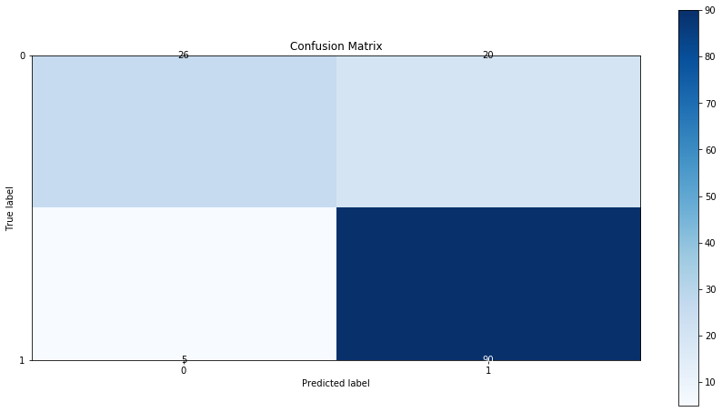

```python
skplt.metrics.plot_confusion_matrix(ytest, log_cross_pred)
plt.show()
```

## ROC AUC curve Analysis:

```python
from sklearn.metrics import precision_score, recall_score, f1_score
```

```python
print('Simple LR model interpretations:')
print("Precision : ", precision_score(ytest, log_pred))
print("Recall : ", recall_score(ytest, log_pred))
print("F1 Score: ", f1_score(ytest, log_pred))
print()
print('Cross Validation model interpretations:')
print("Precision : ", precision_score(ytest, log_cross_pred))
print("Recall : ", recall_score(ytest, log_cross_pred))
print("F1 Score: ", f1_score(ytest, log_cross_pred))
```

```
Simple LR model interpretations:
Precision :  0.8245614035087719
Recall :  0.9894736842105263
F1 Score:  0.8995215311004785

Cross Validation model interpretations:
Precision :  0.8181818181818182
Recall :  0.9473684210526315
F1 Score:  0.8780487804878049
```

**Even we observe that, Simple Model was clearly givig the better prediction that CV.**

```python
from sklearn.metrics import roc_curve, roc_auc_score, precision_recall_curve
```

```python
print('ROC_AUC Score:',roc_auc_score(ytest, log_pred))
```

```
ROC_AUC Score: 0.7773455377574371
```

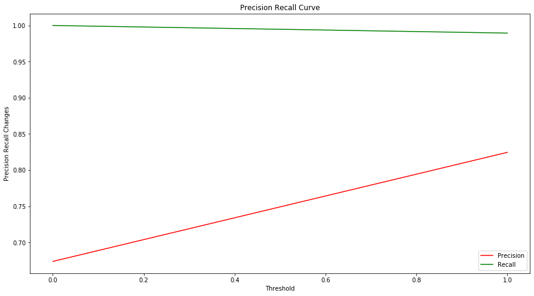

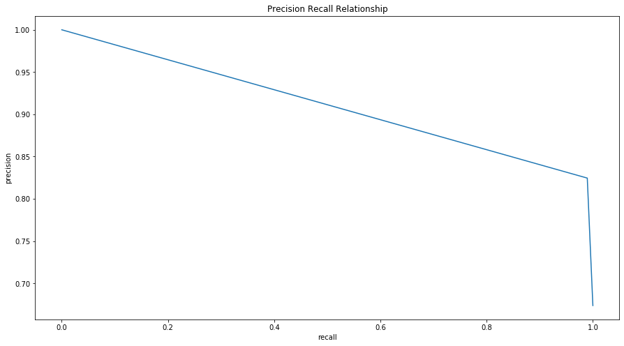

```python
precision, recall, threshold =  precision_recall_curve(ytest, log_pred)
plt.plot(threshold, precision[:-1], c = "r", label = "Precision")
plt.plot(threshold, recall[:-1], c = "g", label = "Recall")
plt.xlabel('Threshold')
plt.ylabel('Precision Recall Changes')
plt.title('Precision Recall Curve')
plt.legend()
plt.show()

plt.plot(recall, precision)
plt.xlabel('recall')
plt.ylabel('precision')
plt.title('Precision Recall Relationship')
plt.show()
```

```
ROC_AUC_Score: 0.7773455377574371
ROC_AUC_Score: 0.7562929061784898
```

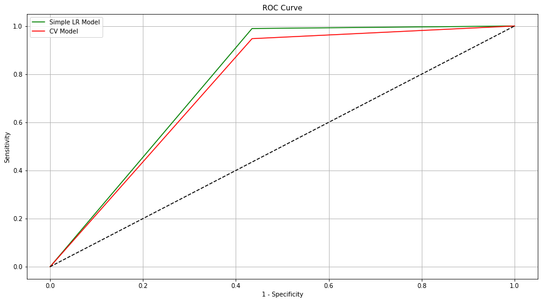

```python
fpr, tpr, th = roc_curve(ytest, log_pred)
fpr1, tpr1, th1 = roc_curve(ytest, log_cross_pred)

print('ROC_AUC_Score:',roc_auc_score(ytest, log_pred))
plt.plot(fpr, tpr, c = 'g', label = 'Simple LR Model')

print('ROC_AUC_Score:',roc_auc_score(ytest, log_cross_pred))
plt.plot(fpr1, tpr1, 'r', label = 'CV Model')

plt.plot([0, 1], [0, 1], 'k--')
plt.xlabel('1 - Specificity')
plt.ylabel('Sensitivity')
plt.title('ROC Curve')
plt.grid()
plt.legend()
plt.show()
```

### All above analysis shows that, the data with simple Logistic Regression with specific maximum iteration and SAGA solver gives better predictions.

### For sake of more curiosity, Let's work on other models as well.

# 2) Naive Bayes

```python
from sklearn.naive_bayes import GaussianNB
```

```python
nb = GaussianNB()
nb.fit(Xtrain, ytrain)
print('Accuracy for train data:',nb.score(Xtrain, ytrain))
print('Accuracy for test data:',nb.score(Xtest, ytest))
```

```
Accuracy for train data: 0.919047619047619
Accuracy for test data: 0.8581560283687943
```

```python
from sklearn.model_selection import cross_val_score
cvs = cross_val_score(nb, Xtrain, ytrain, cv = 3)
cvs
```

```
array([0.92957746, 0.9       , 0.91304348])
```

```python
print('Average Accuracy:',cvs.mean())
```

```
Average Accuracy: 0.914206981016534
```

### One Instance Analysis of Train Test accuracy with all possible values deduction.

```python
from sklearn.metrics import classification_report

print('Classification Report for Train set of data:')
print(classification_report(ytrain, nb.predict(Xtrain)))
print()
print('Classification Report for Test set of data:')
print(classification_report(ytest, nb.predict(Xtest)))
```

```
Classification Report for Train set of data:
              precision    recall  f1-score   support

           0       0.98      0.80      0.88        80
           1       0.89      0.99      0.94       130

    accuracy                           0.92       210
   macro avg       0.94      0.90      0.91       210
weighted avg       0.93      0.92      0.92       210


Classification Report for Test set of data:
              precision    recall  f1-score   support

           0       0.93      0.61      0.74        46
           1       0.84      0.98      0.90        95

    accuracy                           0.86       141
   macro avg       0.89      0.79      0.82       141
weighted avg       0.87      0.86      0.85       141
```

### Let's try deterministic models for prediction of Quality of radar.

# 3) Decision Tree

```python
from sklearn.tree import DecisionTreeClassifier
```

```python
dt = DecisionTreeClassifier()
dt.fit(Xtrain, ytrain)
```

```
DecisionTreeClassifier(class_weight=None, criterion='gini', max_depth=None,
                       max_features=None, max_leaf_nodes=None,
                       min_impurity_decrease=0.0, min_impurity_split=None,
                       min_samples_leaf=1, min_samples_split=2,
                       min_weight_fraction_leaf=0.0, presort=False,
                       random_state=None, splitter='best')
```

```python
print('Accuracy on train data:',dt.score(Xtrain, ytrain))
print('Accuracy on test data:',dt.score(Xtest, ytest))
```

```
Accuracy on train data: 1.0
Accuracy on test data: 0.8368794326241135
```

#### Decison Tree Drawback:

It is a disposition of Decision Tree that it takes the `overfitting` issue ahead.

Let's search optimal cases for Decision Tree elements:

## Grid Search for more accuracy:

```python
from warnings import filterwarnings
filterwarnings('ignore')
```

```python
tune = {'criterion': ['entropy', 'gini'],
       'max_depth':range(2,10)}

from sklearn.model_selection import GridSearchCV
grid_selection = GridSearchCV(estimator = dt, param_grid = tune, cv = 3)
grid_dt_model = grid_selection.fit(Xtrain, ytrain)
print('Best parameters for the model are:', grid_dt_model.best_params_)
```

```
Best parameters for the model are: {'criterion': 'entropy', 'max_depth': 9}
```

```python
dt_grid = DecisionTreeClassifier(criterion = 'entropy', max_depth = 6)
dt_grid.fit(Xtrain, ytrain)

print('Accuracy on train data:',dt_grid.score(Xtrain, ytrain))
print('Accuracy on test data:',dt_grid.score(Xtest, ytest))
```

```
Accuracy on train data: 1.0
Accuracy on test data: 0.8014184397163121
```

```python
print('Classification reports for Train data:')
print(classification_report(ytrain, dt_grid.predict(Xtrain)))
print()
print('Classification report for Test data:')
print(classification_report(ytest, dt_grid.predict(Xtest)))
```

```
Classification reports for Train data:
              precision    recall  f1-score   support

           0       1.00      1.00      1.00        80
           1       1.00      1.00      1.00       130

    accuracy                           1.00       210
   macro avg       1.00      1.00      1.00       210
weighted avg       1.00      1.00      1.00       210


Classification report for Test data:
              precision    recall  f1-score   support

           0       0.71      0.65      0.68        46
           1       0.84      0.87      0.86        95

    accuracy                           0.80       141
   macro avg       0.78      0.76      0.77       141
weighted avg       0.80      0.80      0.80       141
```

It gives the more clearity of the data insightful. Again shows `overfitting`.

Leet's observe the tree of the model:

```python
import pydotplus
from IPython.display import Image
from sklearn import tree
```

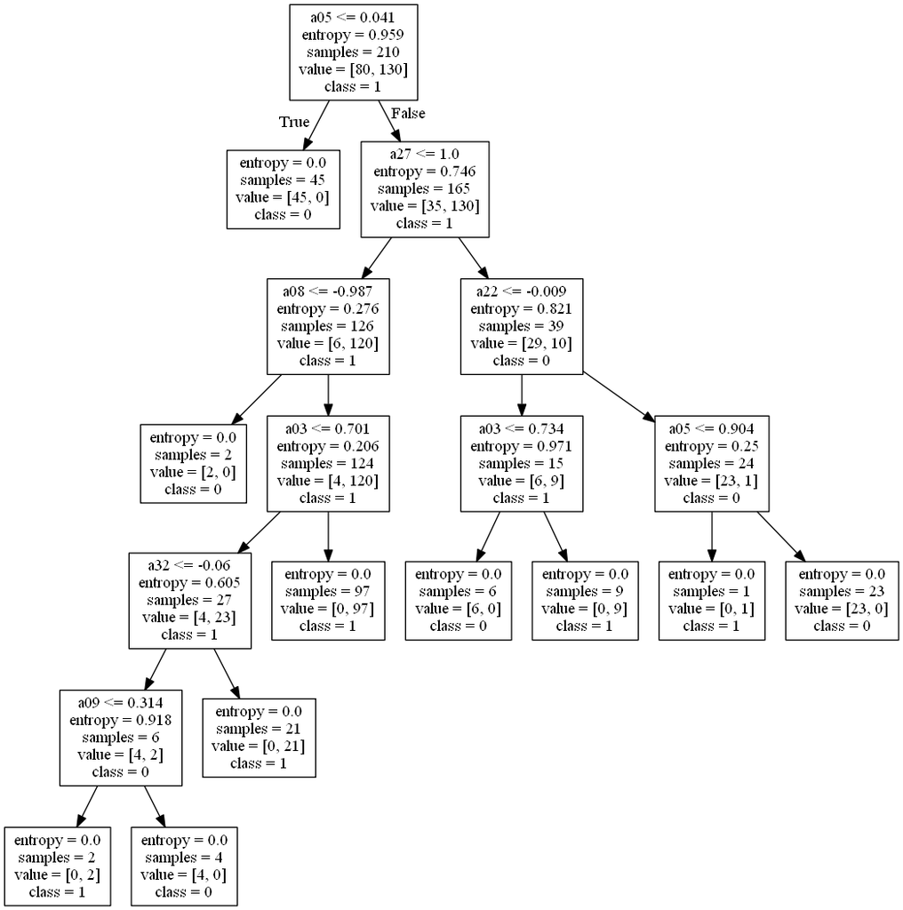

```python
labels = Xtrain.columns

dot_data = tree.export_graphviz(dt_grid, feature_names = labels, class_names = ["0","1"])

graph = pydotplus.graph_from_dot_data(dot_data)

Image(graph.create_png())
```

This is the optimal decision tree to see how the tree has been spread down with specific nodes.

Let's run to a determinstci techniquen to analyse our predictions:

# 4) KNN

```python
from sklearn.neighbors import KNeighborsClassifier
knn = KNeighborsClassifier()
knn.fit(Xtrain, ytrain)
```

```
KNeighborsClassifier(algorithm='auto', leaf_size=30, metric='minkowski',
                     metric_params=None, n_jobs=None, n_neighbors=5, p=2,
                     weights='uniform')
```

```python
print('Accuracy on train data:',knn.score(Xtrain, ytrain))
print('Accuracy on test data:',knn.score(Xtest, ytest))
```

```
Accuracy on train data: 0.8809523809523809
Accuracy on test data: 0.8156028368794326
```

No issues of `overfitting` or `underfitting` of the data, but again the accuracy is good but Logistic Regression is still better model for this experiment.

## Grid Search Analysis:

```python
from warnings import filterwarnings
filterwarnings('ignore')
```

```python
import numpy as np
tune = {'n_neighbors': np.arange(1, 25),
                   'metric': ['hamming','euclidean','manhattan']}

from sklearn.model_selection import GridSearchCV
grid_knn = GridSearchCV(estimator = knn, param_grid = tune, cv = 3, scoring = 'accuracy')
grid_knn_model = grid_knn.fit(Xtrain, ytrain)
print('Best parameters for the model are:', grid_knn_model.best_params_)
print('Accuracy for the model are:', grid_knn_model.best_score_)
```

```
Best parameters for the model are: {'metric': 'manhattan', 'n_neighbors': 2}
Accuracy for the model are: 0.9333333333333333
```

Even we observe that we are about to get the same accuracy as similar as simple knn model. But here in after grid search we see accuracy increased by the term 4% more. Let's have theprediction and fit into the data for furture operation of `Space radar Analysis`.

```python
knn_grid = KNeighborsClassifier(metric = 'manhattan', n_neighbors =  2)
pred_knn = knn_grid.fit(Xtrain, ytrain).predict(Xtest)
```

```python
X_knn = Xtest.copy()
X_knn['class'] = pred_knn
X_knn['class'] = X_knn['class'].replace(to_replace = [1,0], value = ['Good', 'Bad'])
```

```python
df3 = X_knn.iloc[:,-8:].head()
print(df3)
print()
print(ionosphere.iloc[df3.index,-8:].head().replace(to_replace = [1,0], value = ['Good', 'Bad']))
```

```
         a28      a29      a30      a31      a32      a33      a34 class
299 -0.60863  0.08425 -0.61488  0.25164 -0.48468  0.40591 -0.35339  Good
175  0.20225  1.00000  0.05882  1.00000  0.35294  1.00000  0.23529  Good
106  0.10976  0.00000  0.00000  0.00000  0.00000  0.00000  0.00000   Bad
306 -0.14256  0.19444 -0.13889  0.36924 -0.14809  0.08333 -0.50000  Good
342 -0.02731  0.74046 -0.07630  0.70058 -0.04220  0.78439  0.01214  Good

         a28      a29      a30      a31      a32      a33      a34 class
299 -0.60863  0.08425 -0.61488  0.25164 -0.48468  0.40591 -0.35339  Good
175  0.20225     Good  0.05882     Good  0.35294     Good  0.23529  Good
106  0.10976      Bad      Bad      Bad      Bad      Bad      Bad   Bad
306 -0.14256  0.19444 -0.13889  0.36924 -0.14809  0.08333     -0.5  Good
342 -0.02731  0.74046  -0.0763  0.70058  -0.0422  0.78439  0.01214  Good
```

We can see the data, how the sample reprsent the accuracy more than `50%`.

```python
print('Classification reports for Train data:')
print(classification_report(ytrain, knn_grid.predict(Xtrain)))
print()
print('Classification report for Test data:')
print(classification_report(ytest, knn_grid.predict(Xtest)))
```

```
Classification reports for Train data:
              precision    recall  f1-score   support

           0       0.98      1.00      0.99        80
           1       1.00      0.98      0.99       130

    accuracy                           0.99       210
   macro avg       0.99      0.99      0.99       210
weighted avg       0.99      0.99      0.99       210


Classification report for Test data:
              precision    recall  f1-score   support

           0       0.84      0.70      0.76        46
           1       0.86      0.94      0.90        95

    accuracy                           0.86       141
   macro avg       0.85      0.82      0.83       141
weighted avg       0.86      0.86      0.85       141
```

Classification is the also the good technique to follow the analysis of predicitons, but still method goes to represent the `overfitting` issue.

If such case comes up a **Data Scientist** finally approaches to **Ensemble Techniques** which are extremely awesome and good in working.

##### Let's see the Ensemble models.

# Ensemble Techniques

We have 3 members in the family of `Ensemble Techniques`. We eventually mix multple models or single model multiple times the algorithms. This is nothing but **Ensemble Technique**.

# 1) Stacking

```python
from sklearn.ensemble import VotingClassifier
```

We select the best models of all algorithms.

```python
LR1 = LogisticRegression(solver = 'saga', max_iter = 200)
nb1 = GaussianNB()
dt1 = DecisionTreeClassifier(criterion = grid_dt_model.best_params_.get('criterion'),
                                  max_depth = grid_dt_model.best_params_.get('max_depth'))
knn1 = KNeighborsClassifier(metric = grid_knn_model.best_params_.get('metric'),
                           n_neighbors = grid_knn_model.best_params_.get('n_neighbors'))
```

```python
st_vot = VotingClassifier([('Logistic Regression',LR1),
                           ('Naive Bayes',nb1),
                           ('Decision Tree',dt1),
                           ('KNN',knn1)])
```

```python
print('Accuracy with Train data for the model:',st_vot.fit(Xtrain, ytrain).score(Xtrain, ytrain))
print()
print('Accuracy with Train data for the model:',st_vot.fit(Xtrain, ytrain).score(Xtest, ytest))
```

```
Accuracy with Train data for the model: 0.9952380952380953

Accuracy with Train data for the model: 0.8794326241134752
```

## Predictions of Ensemble Stack-Voting:

```python
pred_vot = st_vot.fit(Xtrain, ytrain).predict(Xtest)
```

```python
X_Vot = Xtest.copy()
X_Vot['class'] = pred_vot
X_Vot['class'] = X_Vot['class'].replace(to_replace = [1,0], value = ['Good', 'Bad'])
df4 = X_Vot.iloc[:, -8:]

df5 = df4.head()

print(df5)
print()
print(ionosphere.iloc[df5.index,-8:].head().replace(to_replace = [1,0], value = ['Good', 'Bad']))
```

```
         a28      a29      a30      a31      a32      a33      a34 class
299 -0.60863  0.08425 -0.61488  0.25164 -0.48468  0.40591 -0.35339  Good
175  0.20225  1.00000  0.05882  1.00000  0.35294  1.00000  0.23529  Good
106  0.10976  0.00000  0.00000  0.00000  0.00000  0.00000  0.00000   Bad
306 -0.14256  0.19444 -0.13889  0.36924 -0.14809  0.08333 -0.50000  Good
342 -0.02731  0.74046 -0.07630  0.70058 -0.04220  0.78439  0.01214  Good

         a28      a29      a30      a31      a32      a33      a34 class
299 -0.60863  0.08425 -0.61488  0.25164 -0.48468  0.40591 -0.35339  Good
175  0.20225     Good  0.05882     Good  0.35294     Good  0.23529  Good
106  0.10976      Bad      Bad      Bad      Bad      Bad      Bad   Bad
306 -0.14256  0.19444 -0.13889  0.36924 -0.14809  0.08333     -0.5  Good
342 -0.02731  0.74046  -0.0763  0.70058  -0.0422  0.78439  0.01214  Good
```

```python
df4.shape
```

```
(141, 8)
```

Just the sample showed the **Awesome** result for the data. We are going to store the data in the form of CSV.

```python
Z = ionosphere.drop('class', axis=1)

prediction_Voting = st_vot.fit(Xtrain, ytrain).predict(Z)
```

```python
len(prediction_Voting), ionosphere.shape
```

```
(351, (351, 34))
```

All obsrvations gained...

```python
Data = pd.DataFrame((np.array(ionosphere['class'].values)), prediction_Voting).reset_index()
Data = Data.rename({'index':'Real', 0 : 'Predicted'}, axis = 1)
Accuracy = (Data[Data.Real == Data.Predicted]).shape[0]/Data.shape[0]
```

```python
print('The accuracy on the complete data with Stack Ensemble model is:', round(Accuracy*100,3),'%')
```

```
The accuracy on the complete data with Stack Ensemble model is: 94.872 %
```

`Accuracy is intermediately very much fine.`

## ROC Curve with ROC_AUC score Interpretation :

```
ROC_AUC_Score: 0.9355555555555555
```

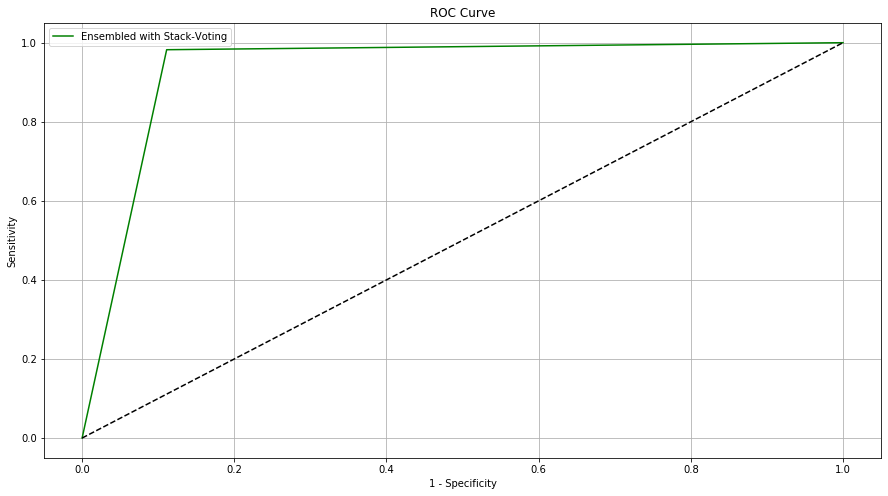

```python
fpr2, tpr2, th2 = roc_curve(ionosphere['class'].values, prediction_Voting)

print('ROC_AUC_Score:',roc_auc_score(ionosphere['class'].values, prediction_Voting))
plt.plot(fpr2, tpr2, c = 'g', label = 'Ensembled with Stack-Voting')


plt.plot([0, 1], [0, 1], 'k--')
plt.xlabel('1 - Specificity')
plt.ylabel('Sensitivity')
plt.title('ROC Curve')
plt.grid()
plt.legend()
plt.show()
```

Plot also proves the accuracy what our model actually gave us...

# Extracion of the Data:

```python
Z['Class'] = prediction_Voting
Z['Class'] = Z['Class'].replace(to_replace = [1,0], value = ['Good', 'Bad'])
Z.iloc[:, -6:].head()
```

|  | a30 | a31 | a32 | a33 | a34 | Class |
| --- | --- | --- | --- | --- | --- | --- |
| 0 | -0.34090 | 0.42267 | -0.54487 | 0.18641 | -0.45300 | Good |
| 1 | -0.11593 | -0.16626 | -0.06288 | -0.13738 | -0.02447 | Good |
| 2 | -0.17365 | 0.60436 | -0.24180 | 0.56045 | -0.38238 | Good |
| 3 | -0.20099 | 0.25682 | 1.00000 | -0.32382 | 1.00000 | Bad |
| 4 | -0.62197 | -0.05707 | -0.59573 | -0.04608 | -0.65697 | Good |

```python
Z.to_csv("ionosphere_Ensemble_Stack.csv",index = False)
```

We have saved our work in another CSV file. We can refer the file for furthur experiments.

###### This data set acquires more memory.

### Good Radars are predicetd Below:

```python
good_radars = np.array(Z[Z.Class == 'Good'].index)
good_radars
```

```
array([  0,   1,   2,   4,   6,   8,  10,  12,  13,  14,  16,  18,  20,
        22,  24,  25,  26,  28,  30,  32,  33,  34,  36,  38,  39,  40,
        42,  44,  46,  48,  50,  52,  54,  56,  58,  60,  62,  64,  65,
        66,  68,  70,  72,  74,  76,  78,  80,  82,  83,  84,  85,  86,
        87,  88,  89,  90,  92,  94,  96,  97,  99, 101, 103, 105, 107,
       109, 111, 113, 115, 116, 117, 119, 121, 123, 125, 127, 129, 131,
       133, 135, 137, 139, 141, 142, 145, 147, 149, 151, 153, 155, 157,
       159, 161, 163, 165, 167, 169, 171, 173, 174, 175, 177, 179, 181,
       183, 185, 187, 191, 193, 195, 197, 199, 201, 203, 205, 207, 209,
       211, 213, 215, 217, 219, 221, 223, 225, 227, 229, 231, 233, 235,
       236, 237, 239, 241, 243, 245, 247, 249, 251, 253, 254, 255, 256,
       257, 258, 259, 260, 261, 262, 263, 264, 265, 266, 267, 268, 269,
       270, 271, 272, 273, 274, 275, 276, 277, 278, 279, 280, 281, 282,
       283, 284, 285, 286, 287, 288, 289, 290, 291, 292, 293, 294, 295,
       296, 297, 298, 299, 300, 301, 302, 303, 304, 305, 306, 308, 309,
       310, 311, 312, 313, 314, 315, 316, 317, 318, 319, 320, 321, 322,
       323, 324, 325, 326, 327, 328, 329, 330, 331, 332, 333, 334, 335,
       336, 337, 338, 339, 341, 342, 343, 344, 345, 346, 347, 348, 349,
       350], dtype=int64)
```

# 2) Bagging: BootStrap Aggregation

```python
from sklearn.ensemble import BaggingClassifier
```

```python
bagg = BaggingClassifier(base_estimator = LR1)
bagg.fit(Xtrain, ytrain)
```

```
BaggingClassifier(base_estimator=LogisticRegression(C=1.0, class_weight=None,
                                                    dual=False,
                                                    fit_intercept=True,
                                                    intercept_scaling=1,
                                                    l1_ratio=None, max_iter=200,
                                                    multi_class='warn',
                                                    n_jobs=None, penalty='l2',
                                                    random_state=None,
                                                    solver='saga', tol=0.0001,
                                                    verbose=0,
                                                    warm_start=False),
                  bootstrap=True, bootstrap_features=False, max_features=1.0,
                  max_samples=1.0, n_estimators=10, n_jobs=None,
                  oob_score=False, random_state=None, verbose=0,
                  warm_start=False)
```

```python
print('Accuracy for the train data:',bagg.score(Xtrain, ytrain))
print('Accuracy for the test data:',bagg.score(Xtest, ytest))
```

```
Accuracy for the train data: 0.9380952380952381
Accuracy for the test data: 0.851063829787234
```

We observe the good accuracy in the model with the data. But it is nothing but the little `overfitting` situation into the data. Still it is not as good as stack ensemble technique, since we are not going with **Bagging** method.

## Random Forest Classifier

```python
from sklearn.ensemble import RandomForestClassifier
```

```python
rf = RandomForestClassifier()
rf.fit(Xtrain, ytrain)
```

```
RandomForestClassifier(bootstrap=True, class_weight=None, criterion='gini',
                       max_depth=None, max_features='auto', max_leaf_nodes=None,
                       min_impurity_decrease=0.0, min_impurity_split=None,
                       min_samples_leaf=1, min_samples_split=2,
                       min_weight_fraction_leaf=0.0, n_estimators=10,
                       n_jobs=None, oob_score=False, random_state=None,
                       verbose=0, warm_start=False)
```

```python
print('Accuracy for the train data:',rf.score(Xtrain, ytrain))
print('Accuracy for the test data:',rf.score(Xtest, ytest))
```

```
Accuracy for the train data: 1.0
Accuracy for the test data: 0.9078014184397163
```

We get the good accuracy, but still we are suffering from the issue of `overfitting`.

```python
tune1 = {'criterion': ['entropy', 'gini'],
       'max_depth':range(2,10)}

from sklearn.model_selection import GridSearchCV
grid_selections = GridSearchCV(estimator = rf, param_grid = tune1, cv = 3)
grid_rf_model = grid_selections.fit(Xtrain, ytrain)
print('Best parameters for the model are:', grid_rf_model.best_params_)
```

```
Best parameters for the model are: {'criterion': 'gini', 'max_depth': 5}
```

```python
grid_rf = RandomForestClassifier(criterion = 'gini', max_depth = 8)
grid_rf.fit(Xtrain, ytrain)
```

```
RandomForestClassifier(bootstrap=True, class_weight=None, criterion='gini',
                       max_depth=8, max_features='auto', max_leaf_nodes=None,
                       min_impurity_decrease=0.0, min_impurity_split=None,
                       min_samples_leaf=1, min_samples_split=2,
                       min_weight_fraction_leaf=0.0, n_estimators=10,
                       n_jobs=None, oob_score=False, random_state=None,
                       verbose=0, warm_start=False)
```

```python
print('Accuracy for the train data:',grid_rf.score(Xtrain, ytrain))
print('Accuracy for the test data:',grid_rf.score(Xtest, ytest))
```

```
Accuracy for the train data: 0.9904761904761905
Accuracy for the test data: 0.8794326241134752
```

Again we get the good accuracy, but still we are suffering from the issue of `overfitting`.

# 2) Boosting

## 1. Adaptive Boosting

```python
from sklearn.ensemble import AdaBoostClassifier
```

```python
ad_boost = AdaBoostClassifier(base_estimator = LR1)
ad_boost.fit(Xtrain, ytrain)
```

```
AdaBoostClassifier(algorithm='SAMME.R',
                   base_estimator=LogisticRegression(C=1.0, class_weight=None,
                                                     dual=False,
                                                     fit_intercept=True,
                                                     intercept_scaling=1,
                                                     l1_ratio=None,
                                                     max_iter=200,
                                                     multi_class='warn',
                                                     n_jobs=None, penalty='l2',
                                                     random_state=None,
                                                     solver='saga', tol=0.0001,
                                                     verbose=0,
                                                     warm_start=False),
                   learning_rate=1.0, n_estimators=50, random_state=None)
```

```python
print('Accuracy for the train data:',ad_boost.score(Xtrain, ytrain))
print('Accuracy for the test data:',ad_boost.score(Xtest, ytest))
```

```
Accuracy for the train data: 0.9238095238095239
Accuracy for the test data: 0.8439716312056738
```

The same situation we got for this Boosting Algorithm of `Ada Boost model`. Little `overfiting` is again an issue. We are still approaching `Stack-Votting`.

Still we are prferring **Stack-Voting** model for the prediction.

## 2. Gradient Boosting

```python
from sklearn.ensemble import GradientBoostingClassifier
```

```python
gr_boost = GradientBoostingClassifier()
gr_boost.fit(Xtrain, ytrain)
```

```
GradientBoostingClassifier(criterion='friedman_mse', init=None,
                           learning_rate=0.1, loss='deviance', max_depth=3,
                           max_features=None, max_leaf_nodes=None,
                           min_impurity_decrease=0.0, min_impurity_split=None,
                           min_samples_leaf=1, min_samples_split=2,
                           min_weight_fraction_leaf=0.0, n_estimators=100,
                           n_iter_no_change=None, presort='auto',
                           random_state=None, subsample=1.0, tol=0.0001,
                           validation_fraction=0.1, verbose=0,
                           warm_start=False)
```

```python
print('Accuracy for the train data:',gr_boost.score(Xtrain, ytrain))
print('Accuracy for the test data:',gr_boost.score(Xtest, ytest))
```

```
Accuracy for the train data: 1.0
Accuracy for the test data: 0.8865248226950354
```

Test score was about 90% on accuracy level but still we face a huge `overfitting` on the set of train with respect to test dataset.

Still we are maintained on the `Stack-Voting` algorithm.

# 3) Extra Trees Classifier

```python
from sklearn.ensemble import ExtraTreesClassifier
```

```python
etc = ExtraTreesClassifier(n_estimators = 20)
etc.fit(Xtrain, ytrain)
```

```
ExtraTreesClassifier(bootstrap=False, class_weight=None, criterion='gini',
                     max_depth=None, max_features='auto', max_leaf_nodes=None,
                     min_impurity_decrease=0.0, min_impurity_split=None,
                     min_samples_leaf=1, min_samples_split=2,
                     min_weight_fraction_leaf=0.0, n_estimators=20, n_jobs=None,
                     oob_score=False, random_state=None, verbose=0,
                     warm_start=False)
```

```python
print('Accuracy for the train data:',etc.score(Xtrain, ytrain))
print('Accuracy for the test data:',etc.score(Xtest, ytest))
```

```
Accuracy for the train data: 1.0
Accuracy for the test data: 0.9078014184397163
```

Again same situation we face according to all 2 members of ensemble. Only `Stack-Voting` algorithm is fabulous for the prediction.

```python
tune2 = {'criterion': ['entropy', 'gini'],
       'max_depth':range(2,10)}

from sklearn.model_selection import GridSearchCV
grid_selections_ = GridSearchCV(estimator = etc, param_grid = tune2, cv = 3)
grid_etc_model = grid_selections_.fit(Xtrain, ytrain)
print('Best parameters for the model are:', grid_etc_model.best_params_)
```

```
Best parameters for the model are: {'criterion': 'entropy', 'max_depth': 5}
```

```python
grid_etc = ExtraTreesClassifier(bootstrap=True, n_estimators = 20, criterion = grid_etc_model.best_params_.get('criterion'),
                                  max_depth = grid_etc_model.best_params_.get('max_depth'))
grid_etc.fit(Xtrain, ytrain)
```

```
ExtraTreesClassifier(bootstrap=True, class_weight=None, criterion='entropy',
                     max_depth=5, max_features='auto', max_leaf_nodes=None,
                     min_impurity_decrease=0.0, min_impurity_split=None,
                     min_samples_leaf=1, min_samples_split=2,
                     min_weight_fraction_leaf=0.0, n_estimators=20, n_jobs=None,
                     oob_score=False, random_state=None, verbose=0,
                     warm_start=False)
```

```python
print('Accuracy for the train data:',grid_etc.score(Xtrain, ytrain))
print('Accuracy for the test data:',grid_etc.score(Xtest, ytest))
```

```
Accuracy for the train data: 0.9666666666666667
Accuracy for the test data: 0.8723404255319149
```

This model is also good for the data, but still we pretend to go with `Stack-Voting`. This model is quite predominant on all the algorithms.

### This is also the best model when I incremented "bootstrap = True" .

## Prediction:

```python
L = ionosphere.drop('class', axis=1)

Grid_etc = ExtraTreesClassifier(bootstrap=True, n_estimators = 20, criterion = 'entropy', max_depth = 7)
Prediction_etc = Grid_etc.fit(Xtrain, ytrain).predict(L)

Etc_Data = pd.DataFrame((np.array(ionosphere['class'].values)), Prediction_etc).reset_index()
Etc_Data = Etc_Data.rename({'index':'Real', 0 : 'Predicted'}, axis = 1)
Etc_Accuracy = (Etc_Data[Etc_Data.Real == Etc_Data.Predicted]).shape[0]/Etc_Data.shape[0]
```

```python
print('The accuracy on the complete data with Stack Ensemble model is:', round(Etc_Accuracy*100,3),'%')
```

```
The accuracy on the complete data with Stack Ensemble model is: 94.017 %
```

# EXtraction of the data:

```python
L['Class '] = Prediction_etc
L['Class '] = L['Class '].replace(to_replace = [1,0], value = ['Good', 'Bad'])
L.iloc[:, -6:].head()
```

|  | a30 | a31 | a32 | a33 | a34 | Class |
| --- | --- | --- | --- | --- | --- | --- |
| 0 | -0.34090 | 0.42267 | -0.54487 | 0.18641 | -0.45300 | Good |
| 1 | -0.11593 | -0.16626 | -0.06288 | -0.13738 | -0.02447 | Bad |
| 2 | -0.17365 | 0.60436 | -0.24180 | 0.56045 | -0.38238 | Good |
| 3 | -0.20099 | 0.25682 | 1.00000 | -0.32382 | 1.00000 | Bad |
| 4 | -0.62197 | -0.05707 | -0.59573 | -0.04608 | -0.65697 | Good |

```python
L.to_csv("ionosphere_Ensemble_Extra_Trees.csv",index = False)
```

Both `Stack` and `Extra tree` data have approximately similar in weight with memory gain.

**Reason, why Stack-Voting and Extra Tree Classifier is better for data?**

- The first thing is we got 95% accuracy compared to the entire data. Since we observed it was a little imbalanced, even in that cercumstance we got a good accuracy.
- Even Logistic Regression gave a good accuracy, but the it wasn't on the complete data.

```python
Q = ionosphere.drop('class', axis=1)

Log_reg = LogisticRegression(solver = 'saga', max_iter = 200)
Prediction_Log = Log_reg.fit(Xtrain, ytrain).predict(Q)

Log_Data = pd.DataFrame((np.array(ionosphere['class'].values)), Prediction_Log).reset_index()
Log_Data = Log_Data.rename({'index':'Real', 0 : 'Predicted'}, axis = 1)
Log_Accuracy = (Log_Data[Log_Data.Real == Log_Data.Predicted]).shape[0]/Log_Data.shape[0]
```

```python
print('The accuracy on the complete data with Stack Ensemble model is:', round(Log_Accuracy*100,3),'%')
```

```
The accuracy on the complete data with Stack Ensemble model is: 90.598 %
```

- And we see, even we had a good accuracy in **Logistic Regression**, but that was not as good as Stack-Ensemble model.
- Finally we can say, that Stack-Voting works on each member of the Ensemble family, and we adjusted all the algorithms with their best respeetive parameters. Hence It is preferrable to go with this technique.
- The same answer is for Extra-Tree-Classifier. Both the algorithms are doing so well. Hence we extracted the data form both the models. Which can be used in further experiments.
- Above below is definitely fine, since the train and test are being selected randomly.